# AMP-AD analysis

Shea Andrews

2/24/2020

# Association of mtDNA-CN with Alzheimer’s disease

## MSBB

Sample exclusion

- non-white (55)

mtDNA-CN was standardized

### Clinical Diagnosis

- Clinical Dementia (CDR)
  - Dementia: CDR > 0.5
  - Control: CDR <= 0.5

GLM: DX ~ mtDNA + Age of Death + APOE + Sex

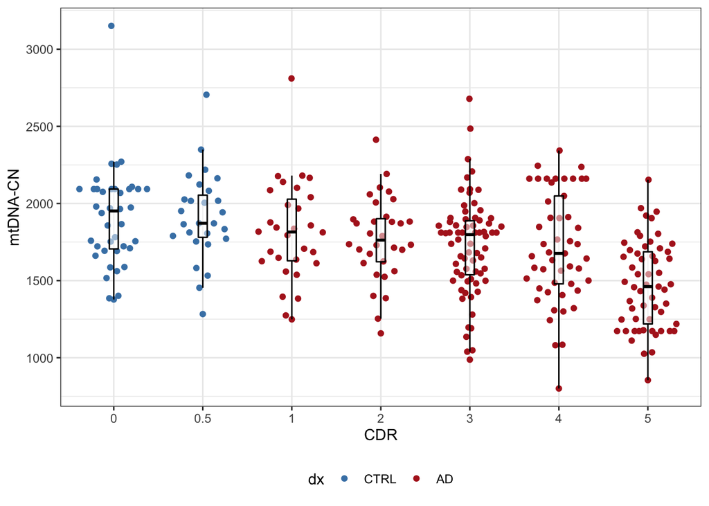

| term | estimate | std.error | conf.low | conf.high | statistic | p.value |
| --- | --- | --- | --- | --- | --- | --- |
| (Intercept) | 0.04 | 1.58 | 0.00 | 0.92 | -2.00 | 0.0458688 |
| z_mtdnacn | 0.48 | 0.17 | 0.34 | 0.65 | -4.49 | 0.0000073 |
| aod | 1.05 | 0.02 | 1.01 | 1.09 | 2.72 | 0.0065141 |
| sexM | 1.68 | 0.34 | 0.87 | 3.35 | 1.51 | 0.1299227 |
| apoe4e4+ | 2.52 | 0.35 | 1.30 | 5.12 | 2.66 | 0.0077651 |

### Neuropathological Diagnosis (CERAD)

- CERAD Neuropathology Confirmed
  - AD: Definite + Probable
  - Control: Possible + No AD

GLM: DX ~ mtDNA + Age of Death + APOE + Sex

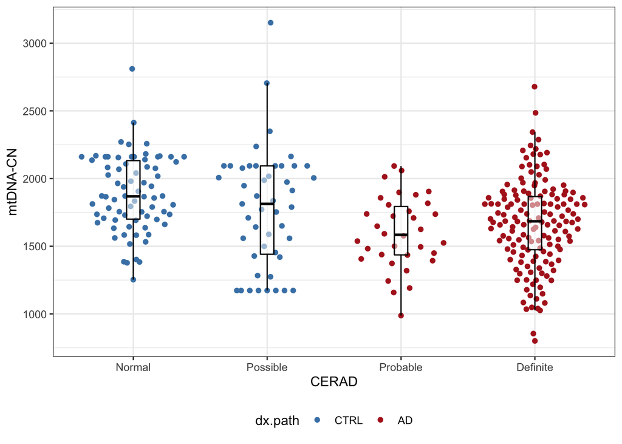

| term | estimate | std.error | conf.low | conf.high | statistic | p.value |
| --- | --- | --- | --- | --- | --- | --- |
| (Intercept) | 0.14 | 1.35 | 0.01 | 1.89 | -1.47 | 0.1403314 |
| z_mtdnacn | 0.54 | 0.14 | 0.41 | 0.70 | -4.54 | 0.0000057 |
| aod | 1.03 | 0.02 | 1.00 | 1.06 | 1.72 | 0.0859028 |
| sexM | 1.36 | 0.28 | 0.79 | 2.37 | 1.11 | 0.2660011 |
| apoe4e4+ | 1.44 | 0.26 | 0.86 | 2.42 | 1.38 | 0.1663904 |

## ROSMAP

Sample exclusion

```r
rosmap.analysis <- rosmap %>%
  filter(race == 1) %>%
  filter(dx.raw != 6) %>%
  filter(organ != 'lymphocytes') %>%
  filter(aod_cat != '60-69') %>%
  mutate(dx.raw = fct_recode(dx.raw, NCI = '1', MCI = '2', MCI = '3', AD = '4', AD = '5'),
         SourceTissue_lmp = fct_lump(SourceTissue, n = 4)) #%>%
 # filter(macro %in% c('H', 'V', 'J', 'T', 'U', 'K', 'I', 'W', 'X'))
```

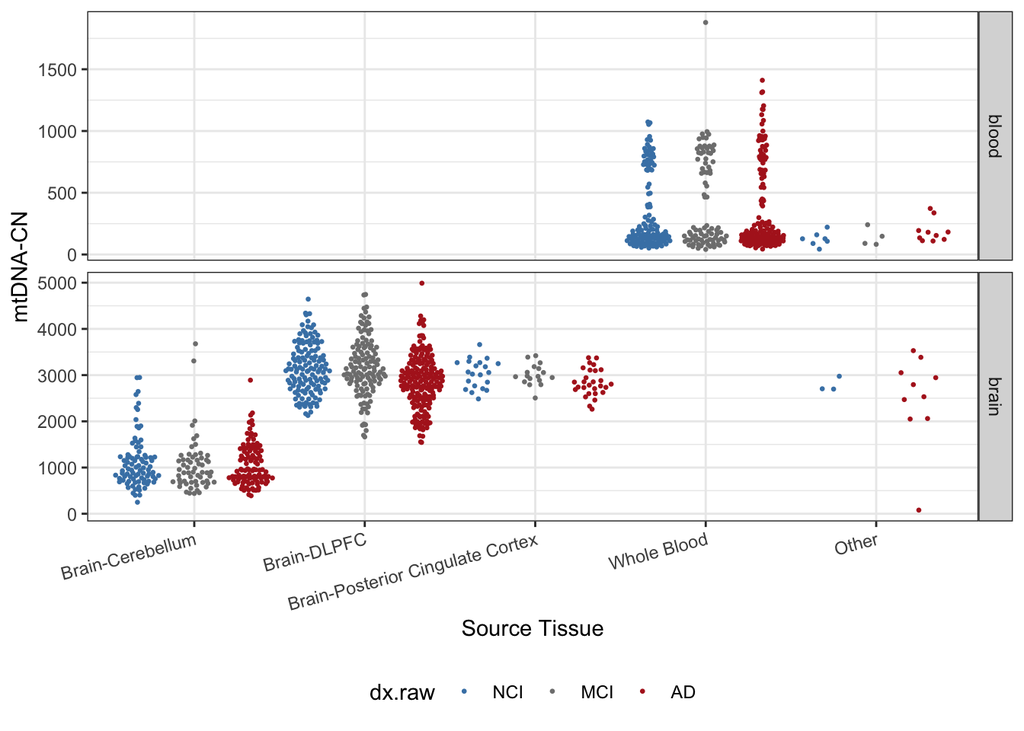

### Clinical Diagnosis

GLM: DX ~ mtDNA-CN + Age of Death (categorical) + Sex + apoe4 + study + Source Tissue

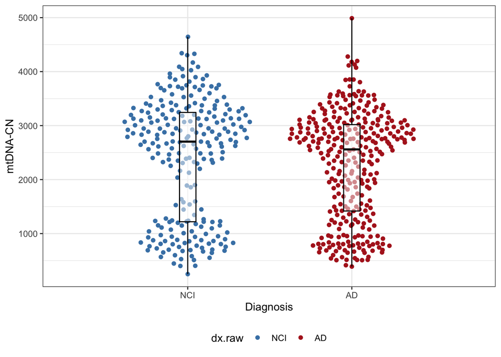

| term | estimate | std.error | conf.low | conf.high | statistic | p.value |
| --- | --- | --- | --- | --- | --- | --- |
| (Intercept) | 0.43 | 0.24 | 0.27 | 0.70 | -3.41 | 0.0006543 |
| z_mtdnacn | 0.49 | 0.24 | 0.31 | 0.77 | -3.02 | 0.0025121 |
| aod_cat.L | 4.45 | 0.28 | 2.63 | 7.95 | 5.32 | 0.0000001 |
| aod_cat.Q | 0.86 | 0.19 | 0.59 | 1.25 | -0.77 | 0.4433892 |
| sex1 | 0.94 | 0.20 | 0.63 | 1.40 | -0.31 | 0.7547659 |
| apoe4e4+ | 3.08 | 0.22 | 2.00 | 4.83 | 5.01 | 0.0000005 |
| studyROS | 1.26 | 0.19 | 0.86 | 1.85 | 1.19 | 0.2338577 |
| SourceTissueBrain-DLPFC | 2.87 | 0.40 | 1.32 | 6.34 | 2.64 | 0.0082716 |
| SourceTissueBrain-Posterior Cingulate Cortex | 2.39 | 0.48 | 0.94 | 6.17 | 1.83 | 0.0679215 |

## Mayo Clinic

Sample exclusion

- Pathologic Aging + PSP (157)
- age 50-59 (3)

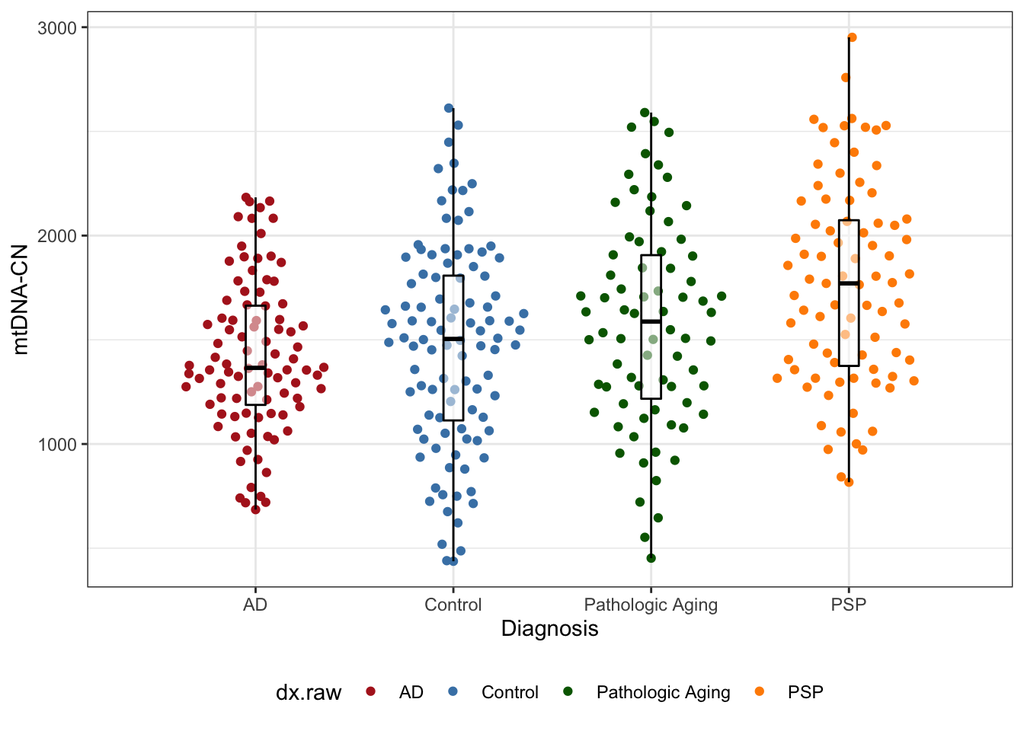

```r
mayo.mtdna <- mayo %>%
  filter(dx.raw %in% c('AD', 'Control')) %>%
  filter(aod_cat != '50-59') %>%
  mutate(dx.raw = fct_drop(dx.raw),
         dx.raw = fct_relevel(dx.raw, 'Control', 'AD')) #%>%
 # filter(macro %in% c('H', 'V', 'J', 'T', 'U', 'K', 'I', 'W', 'X'))
```

GLM: DX ~ mtDNA-CN + Age of Death (categorical) + Sex + apoe4

| term | estimate | std.error | conf.low | conf.high | statistic | p.value |
| --- | --- | --- | --- | --- | --- | --- |
| (Intercept) | 0.78 | 0.30 | 0.43 | 1.41 | -0.82 | 0.4105442 |
| z_mtdnacn | 1.02 | 0.19 | 0.70 | 1.50 | 0.12 | 0.9032735 |
| aod_cat.L | 0.67 | 0.47 | 0.26 | 1.67 | -0.85 | 0.3970250 |
| aod_cat.Q | 1.90 | 0.42 | 0.85 | 4.41 | 1.54 | 0.1227674 |
| aod_cat.C | 0.77 | 0.36 | 0.38 | 1.55 | -0.73 | 0.4653313 |
| sexM | 0.74 | 0.36 | 0.37 | 1.49 | -0.84 | 0.3995695 |
| apoe4e4+ | 8.12 | 0.41 | 3.78 | 18.96 | 5.13 | 0.0000003 |

# Association of mitochondrial haplogroups with Alzheimer’s disease

## MSBB

Sample exclusion

- non-white (n = 55)
- non-European Haplogroups (n = 84)
- Haplogroup Quality (3)

```r
msbb.hg <- msbb %>%
  filter(race == 'W') %>%
  filter(macro %in% c('H', 'V', 'J', 'T', 'U', 'K', 'I', 'W', 'X')) %>%
  filter(Quality > 0.8) %>%
  mutate(dx = ifelse(cdr <= 0.5, 'CTRL', 'AD'),
         dx = fct_relevel(dx, 'CTRL', 'AD'),
         dx.path = ifelse(cerad %in% c('Normal','Possible'), 'CTRL', 'AD'),
         dx.path = fct_relevel(dx.path, 'CTRL', 'AD'),
         macro = fct_drop(macro),
         macro_lmp = fct_lump(macro, n = 6),
         macro_lmp = fct_recode(macro_lmp, IWX = 'Other'))
```

### Clinical Diagnosis

- Clinical Dementia (CDR)
  - Dementia: CDR > 0.5
  - Control: CDR <= 0.5

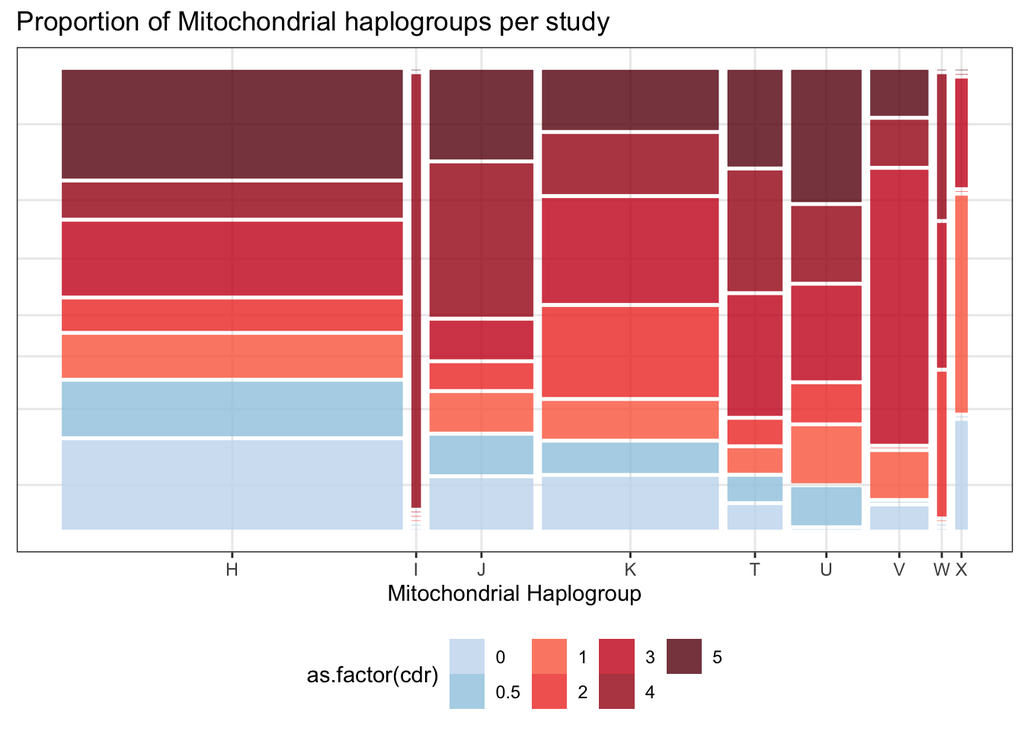

| term | estimate | std.error | conf.low | conf.high | statistic | p.value |
| --- | --- | --- | --- | --- | --- | --- |
| (Intercept) | 0.04 | 1.80 | 0.00 | 1.19 | -1.84 | 0.0653301 |
| macro_lmpJ | 2.88 | 0.54 | 1.06 | 8.84 | 1.97 | 0.0487783 |
| macro_lmpK | 1.77 | 0.44 | 0.77 | 4.30 | 1.31 | 0.1895717 |
| macro_lmpT | 5.24 | 0.85 | 1.18 | 37.87 | 1.95 | 0.0509655 |
| macro_lmpU | 4.27 | 0.81 | 1.04 | 29.19 | 1.79 | 0.0731802 |
| macro_lmpV | 8.46 | 1.07 | 1.53 | 159.12 | 1.99 | 0.0465963 |
| macro_lmpIWX | 4.06 | 1.10 | 0.67 | 78.64 | 1.27 | 0.2033028 |
| aod | 1.04 | 0.02 | 1.00 | 1.09 | 2.15 | 0.0317199 |
| sexM | 1.77 | 0.39 | 0.83 | 3.94 | 1.45 | 0.1477620 |
| apoe4e4+ | 2.88 | 0.39 | 1.39 | 6.34 | 2.74 | 0.0060884 |
| z_mtdnacn | 0.39 | 0.20 | 0.26 | 0.56 | -4.77 | 0.0000019 |

### Neuropathological Diagnosis (CERAD)

- CERAD Neuropathology Confirmed
- AD: Definite + Probable
- Control: Possible + No AD

GLM: DX ~ haplogroup + Age of Death + APOE + Sex

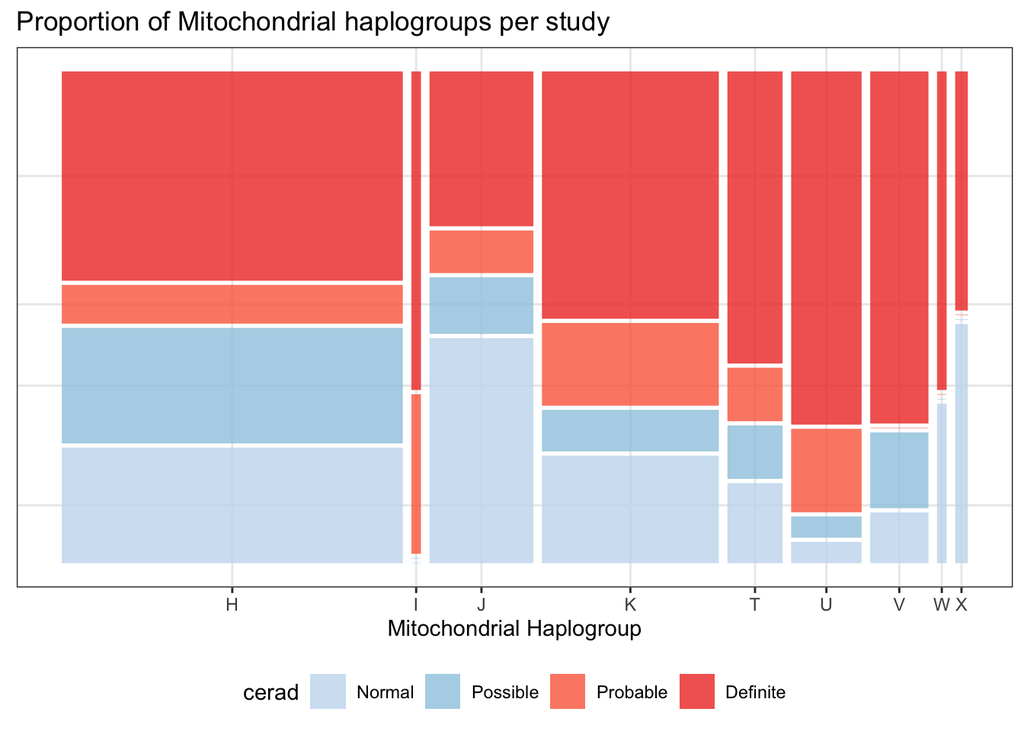

| term | estimate | std.error | conf.low | conf.high | statistic | p.value |
| --- | --- | --- | --- | --- | --- | --- |
| (Intercept) | 0.31 | 1.42 | 0.02 | 5.08 | -0.82 | 0.4142047 |
| macro_lmpJ | 0.64 | 0.40 | 0.29 | 1.40 | -1.11 | 0.2663275 |
| macro_lmpK | 1.95 | 0.35 | 1.00 | 3.91 | 1.92 | 0.0548045 |
| macro_lmpT | 2.57 | 0.56 | 0.89 | 8.52 | 1.67 | 0.0945797 |
| macro_lmpU | 9.53 | 0.77 | 2.60 | 61.70 | 2.94 | 0.0032981 |
| macro_lmpV | 2.62 | 0.57 | 0.91 | 8.74 | 1.70 | 0.0892651 |
| macro_lmpIWX | 2.10 | 0.72 | 0.55 | 10.22 | 1.03 | 0.3029018 |
| aod | 1.01 | 0.02 | 0.98 | 1.04 | 0.74 | 0.4612851 |
| sexM | 1.28 | 0.30 | 0.71 | 2.34 | 0.82 | 0.4116841 |
| apoe4e4+ | 1.53 | 0.28 | 0.89 | 2.66 | 1.54 | 0.1245010 |

## ROSMAP

Sample exclusion

- non-white (2)
- MCI + Other (318)
- missing mtDNA (17)
- non-European haplogroups (34)
- Haplogroup Quality (20)
- age 60-69 (2)

```r
rosmap.hg <- rosmap.analysis %>%
  filter(SourceTissue_lmp != 'Other') %>%
  filter(macro %in% c('H', 'V', 'J', 'T', 'U', 'K', 'I', 'W', 'X'))  %>%
  filter(Quality > 0.8) %>%
  mutate(macro = fct_drop(macro),
         aod_cat = fct_drop(aod_cat),
         dx.raw = fct_drop(dx.raw))
```

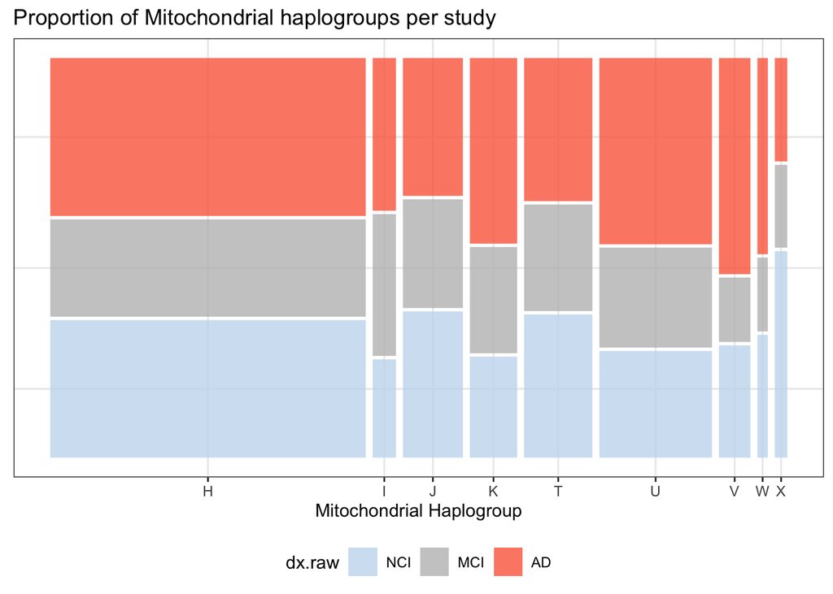

GLM: Diagnosis ~ Haplgroup + Age of Death (categorical) + Sex + apoe4 + study + Source Tissue

| term | estimate | std.error | conf.low | conf.high | statistic | p.value |
| --- | --- | --- | --- | --- | --- | --- |
| (Intercept) | 0.54 | 0.22 | 0.35 | 0.83 | -2.79 | 0.0052672 |
| macroI | 1.45 | 0.47 | 0.59 | 3.73 | 0.79 | 0.4296101 |
| macroJ | 0.86 | 0.28 | 0.49 | 1.49 | -0.55 | 0.5820886 |
| macroK | 1.56 | 0.33 | 0.83 | 3.00 | 1.36 | 0.1739120 |
| macroT | 0.76 | 0.27 | 0.44 | 1.29 | -1.02 | 0.3060748 |
| macroU | 1.63 | 0.23 | 1.05 | 2.54 | 2.15 | 0.0313680 |
| macroV | 1.68 | 0.37 | 0.83 | 3.52 | 1.41 | 0.1590177 |
| macroW | 1.67 | 0.62 | 0.50 | 6.01 | 0.82 | 0.4105204 |
| macroX | 0.41 | 0.59 | 0.12 | 1.26 | -1.51 | 0.1299091 |
| aod_cat.L | 4.41 | 0.24 | 2.81 | 7.16 | 6.24 | 0.0000000 |
| aod_cat.Q | 0.94 | 0.16 | 0.68 | 1.28 | -0.39 | 0.6945843 |
| sex1 | 0.93 | 0.17 | 0.67 | 1.30 | -0.41 | 0.6831211 |
| apoe4e4+ | 3.39 | 0.19 | 2.36 | 4.95 | 6.48 | 0.0000000 |
| studyROS | 1.54 | 0.16 | 1.12 | 2.11 | 2.65 | 0.0081286 |
| SourceTissue_lmpBrain-DLPFC | 0.90 | 0.21 | 0.59 | 1.34 | -0.53 | 0.5931270 |
| SourceTissue_lmpBrain-Posterior Cingulate Cortex | 0.79 | 0.36 | 0.39 | 1.62 | -0.65 | 0.5165371 |
| SourceTissue_lmpWhole Blood | 0.69 | 0.22 | 0.45 | 1.07 | -1.66 | 0.0972684 |

## Mayo

- non-European haplogroups (4)
- Haplogroup Quality (1)

```r
mayo.hg <- mayo.mtdna %>%
  filter(macro %in% c('H', 'V', 'J', 'T', 'U', 'K', 'I', 'W', 'X'))  %>%
  filter(Quality > 0.8) %>%
  mutate(macro = fct_drop(macro),
         aod_cat = fct_drop(aod_cat),
         dx.raw = fct_drop(dx.raw),
         macro_lmp = fct_lump(macro, n = 6),
         macro_lmp = fct_recode(macro_lmp, IWX = 'Other'))
```

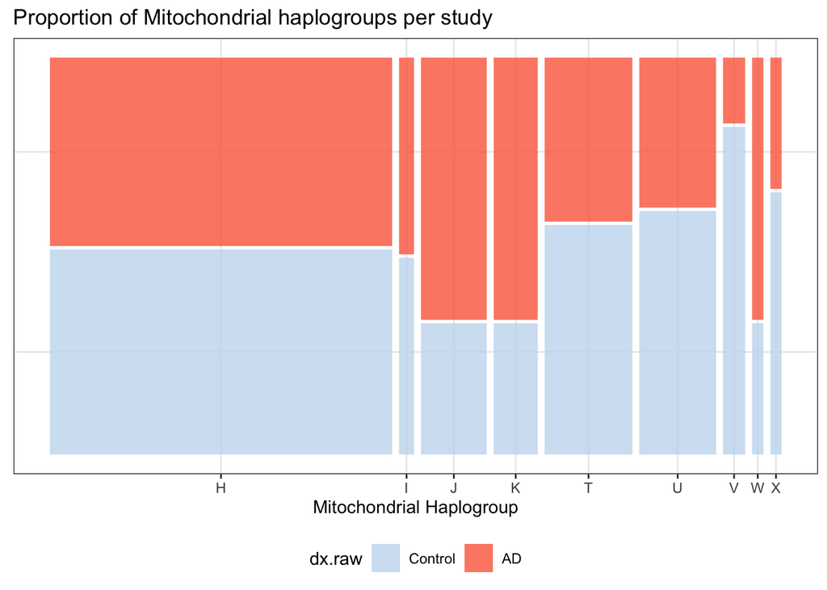

GLM: Diagnosis ~ Haplgroup + Age of Death (categorical) + Sex + apoe4

| term | estimate | std.error | conf.low | conf.high | statistic | p.value |
| --- | --- | --- | --- | --- | --- | --- |
| (Intercept) | 0.87 | 0.36 | 0.42 | 1.76 | -0.40 | 0.6877005 |
| macro_lmpJ | 1.29 | 0.63 | 0.38 | 4.62 | 0.41 | 0.6838490 |
| macro_lmpK | 2.76 | 0.69 | 0.73 | 11.82 | 1.46 | 0.1434333 |
| macro_lmpT | 0.48 | 0.57 | 0.15 | 1.42 | -1.30 | 0.1949541 |
| macro_lmpU | 0.44 | 0.66 | 0.11 | 1.56 | -1.24 | 0.2136344 |
| macro_lmpV | 0.06 | 1.26 | 0.00 | 0.51 | -2.30 | 0.0215642 |
| macro_lmpIWX | 1.28 | 0.79 | 0.26 | 6.25 | 0.31 | 0.7562050 |
| aod_cat.L | 0.76 | 0.50 | 0.27 | 2.02 | -0.56 | 0.5780666 |
| aod_cat.Q | 1.78 | 0.44 | 0.76 | 4.35 | 1.31 | 0.1894363 |
| aod_cat.C | 0.79 | 0.39 | 0.37 | 1.67 | -0.62 | 0.5328011 |
| sexM | 0.63 | 0.38 | 0.30 | 1.33 | -1.21 | 0.2249960 |
| apoe4e4+ | 10.86 | 0.47 | 4.57 | 29.21 | 5.09 | 0.0000004 |

# Association of mitochondrial haplogroups with mtDNA-CN

## MSBB

Sample exclusion

- non-white (n = 55)
- non-European Haplogroups (n = 84)

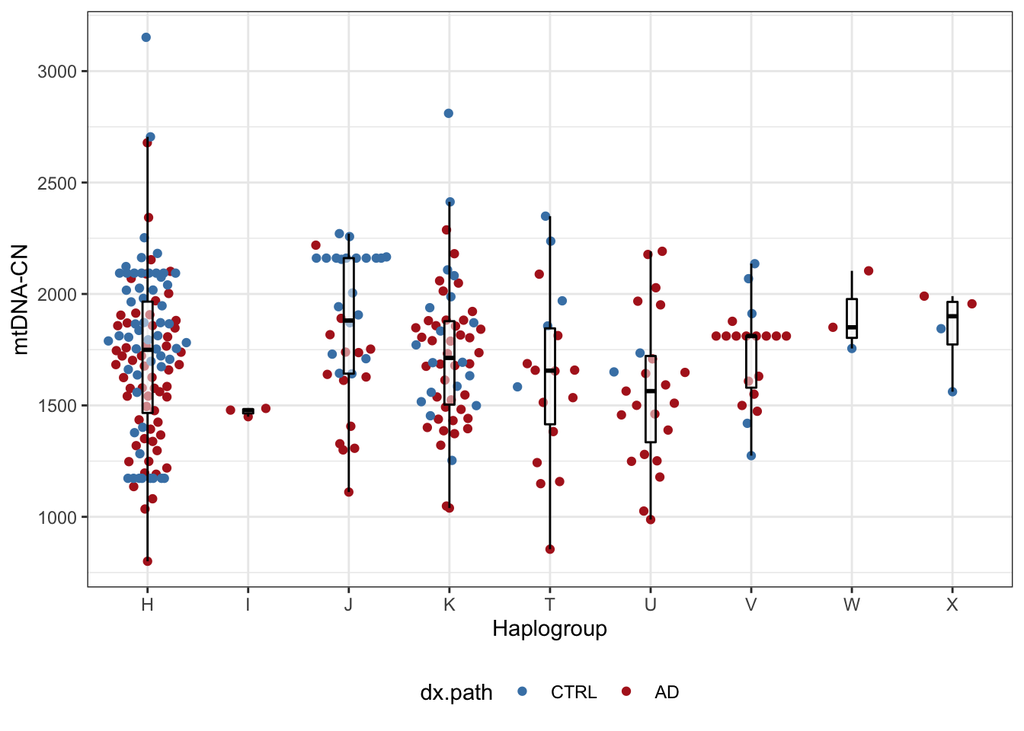

```r
ggplot(msbb.hg, aes(x = as.factor(macro), y = mtcn_avg, colour = dx.path)) +
  geom_quasirandom() +
  scale_color_manual(values = c('steelblue', 'firebrick')) +
  geom_boxplot(colour = 'black', alpha = 0.5, width = 0.1, outlier.shape = NA) +
  labs(x = 'Haplogroup', y = 'mtDNA-CN') +
  theme_bw() + theme(legend.position = 'bottom')
```

LM: mtDNA-CN ~ haplogroup + CDR + Age of Death + APOE + Sex

| term | estimate | std.error | conf.low | conf.high | statistic | p.value |
| --- | --- | --- | --- | --- | --- | --- |
| (Intercept) | -0.08 | 0.61 | -1.27 | 1.11 | -0.13 | 0.8951183 |
| macro_lmpJ | 0.55 | 0.18 | 0.20 | 0.90 | 3.07 | 0.0023401 |
| macro_lmpK | 0.02 | 0.15 | -0.28 | 0.31 | 0.12 | 0.9040160 |
| macro_lmpT | -0.04 | 0.23 | -0.50 | 0.42 | -0.16 | 0.8764082 |
| macro_lmpU | -0.21 | 0.21 | -0.62 | 0.20 | -1.00 | 0.3204864 |
| macro_lmpV | 0.16 | 0.23 | -0.30 | 0.61 | 0.68 | 0.4996245 |
| macro_lmpIWX | 0.13 | 0.30 | -0.46 | 0.72 | 0.44 | 0.6605339 |
| cdr | -0.25 | 0.03 | -0.31 | -0.18 | -7.61 | 0.0000000 |
| aod | 0.01 | 0.01 | -0.01 | 0.02 | 1.09 | 0.2774572 |
| sexM | 0.05 | 0.13 | -0.20 | 0.30 | 0.42 | 0.6765679 |
| apoe4e4+ | 0.03 | 0.12 | -0.21 | 0.27 | 0.25 | 0.8018313 |

## ROSMAP

Sample exclusion

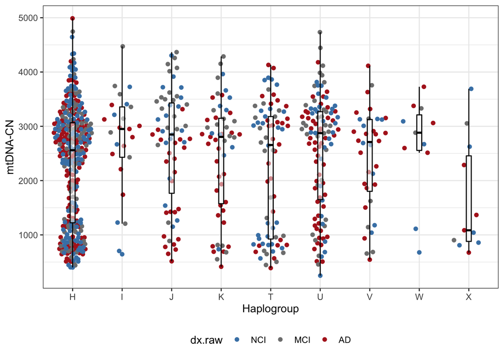

```r
rosmap.hg %>%
  filter(organ == 'brain') %>%
  ggplot(., aes(x = as.factor(macro), y = mtcn_avg, colour = dx.raw)) +
  geom_quasirandom() +
  scale_color_manual(values = c('steelblue', 'grey50', 'firebrick')) +
  geom_boxplot(colour = 'black', alpha = 0.5, width = 0.1, outlier.shape = NA) +
  labs(x = 'Haplogroup', y = 'mtDNA-CN') +
  theme_bw() + theme(legend.position = 'bottom')
```

LM : mtDNA-CN ~ haplogroup + DX + Age of Death + APOE + Sex + Study + Source Tissue

| term | estimate | std.error | conf.low | conf.high | statistic | p.value |
| --- | --- | --- | --- | --- | --- | --- |
| (Intercept) | -0.4120404 | 0.0444907 | -0.4994421 | -0.3246387 | -9.2612706 | 0.0000000 |
| macroI | -0.0099599 | 0.1008102 | -0.2080009 | 0.1880810 | -0.0987989 | 0.9213357 |
| macroJ | 0.0033475 | 0.0670430 | -0.1283579 | 0.1350530 | 0.0499311 | 0.9601963 |
| macroK | -0.0581910 | 0.0705980 | -0.1968802 | 0.0804982 | -0.8242586 | 0.4101670 |
| macroT | 0.0557500 | 0.0594945 | -0.0611266 | 0.1726266 | 0.9370605 | 0.3491583 |
| macroU | 0.0085057 | 0.0509297 | -0.0915453 | 0.1085566 | 0.1670083 | 0.8674278 |
| macroV | -0.0498508 | 0.0783196 | -0.2037092 | 0.1040076 | -0.6365046 | 0.5247250 |
| macroW | -0.0172732 | 0.1376321 | -0.2876504 | 0.2531040 | -0.1255028 | 0.9001736 |
| macroX | -0.0559605 | 0.1373097 | -0.3257045 | 0.2137834 | -0.4075498 | 0.6837703 |
| dxAD | -0.1124458 | 0.0377161 | -0.1865388 | -0.0383528 | -2.9813763 | 0.0030027 |
| aod_cat.L | -0.0456222 | 0.0477934 | -0.1395120 | 0.0482676 | -0.9545710 | 0.3402340 |
| aod_cat.Q | 0.0061190 | 0.0337170 | -0.0601178 | 0.0723557 | 0.1814800 | 0.8560609 |
| sex1 | 0.0213587 | 0.0377457 | -0.0527923 | 0.0955098 | 0.5658595 | 0.5717311 |
| apoe4e4+ | -0.1400598 | 0.0401743 | -0.2189820 | -0.0611377 | -3.4863039 | 0.0005308 |
| studyROS | 0.0799730 | 0.0358179 | 0.0096089 | 0.1503371 | 2.2327630 | 0.0259854 |
| SourceTissue_lmpBrain-DLPFC | 1.4416755 | 0.0384343 | 1.3661715 | 1.5171794 | 37.5101061 | 0.0000000 |
| SourceTissue_lmpBrain-Posterior Cingulate Cortex | 1.3989332 | 0.0674404 | 1.2664470 | 1.5314194 | 20.7432530 | 0.0000000 |

## Mayo

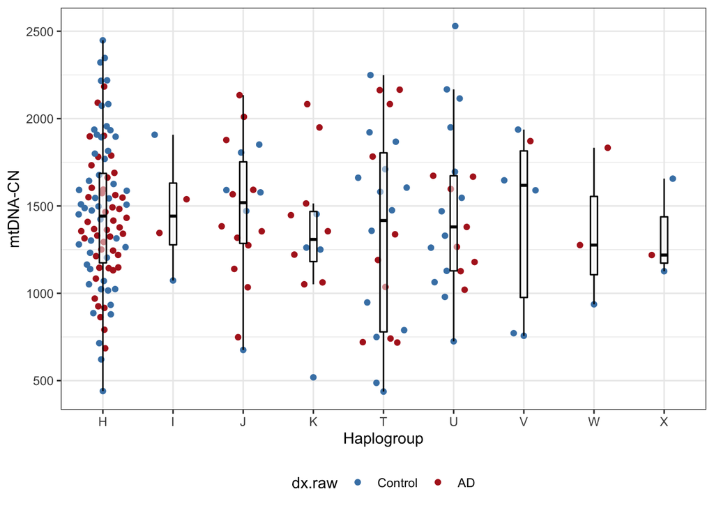

```r
mayo.hg %>%
  ggplot(., aes(x = as.factor(macro), y = mtcn_avg, colour = dx.raw)) +
  geom_quasirandom() +
  scale_color_manual(values = c('steelblue', 'firebrick')) +
  geom_boxplot(colour = 'black', alpha = 0.5, width = 0.1, outlier.shape = NA) +
  labs(x = 'Haplogroup', y = 'mtDNA-CN') +
  theme_bw() + theme(legend.position = 'bottom')
```

LM : mtDNA-CN ~ haplogroup + DX + Age of Death + APOE + Sex

| term | estimate | std.error | conf.low | conf.high | statistic | p.value |
| --- | --- | --- | --- | --- | --- | --- |
| (Intercept) | -0.1663513 | 0.1618359 | -0.4859921 | 0.1532895 | -1.0279010 | 0.3055674 |
| macro_lmpJ | 0.1154345 | 0.2336262 | -0.3459988 | 0.5768679 | 0.4940991 | 0.6219224 |
| macro_lmpK | -0.1872972 | 0.2825026 | -0.7452659 | 0.3706715 | -0.6629927 | 0.5083013 |
| macro_lmpT | -0.1729274 | 0.2116391 | -0.5909342 | 0.2450794 | -0.8170862 | 0.4151095 |
| macro_lmpU | -0.0317042 | 0.2410584 | -0.5078167 | 0.4444083 | -0.1315207 | 0.8955307 |
| macro_lmpV | -0.0422357 | 0.3923693 | -0.8172011 | 0.7327297 | -0.1076428 | 0.9144156 |
| macro_lmpIWX | -0.0658362 | 0.3175755 | -0.6930769 | 0.5614046 | -0.2073087 | 0.8360357 |
| dx.rawAD | 0.0405023 | 0.1561075 | -0.2678244 | 0.3488290 | 0.2594514 | 0.7956247 |
| aod_cat.L | 0.2067424 | 0.1914108 | -0.1713115 | 0.5847963 | 1.0800981 | 0.2817445 |
| aod_cat.Q | -0.0126359 | 0.1653027 | -0.3391240 | 0.3138521 | -0.0764412 | 0.9391648 |
| aod_cat.C | -0.0294883 | 0.1448109 | -0.3155032 | 0.2565267 | -0.2036330 | 0.8389023 |
| sexM | -0.2327667 | 0.1464475 | -0.5220139 | 0.0564806 | -1.5894205 | 0.1139645 |
| apoe4e4+ | -0.1681179 | 0.1699650 | -0.5038145 | 0.1675787 | -0.9891322 | 0.3241108 |

# DIAN

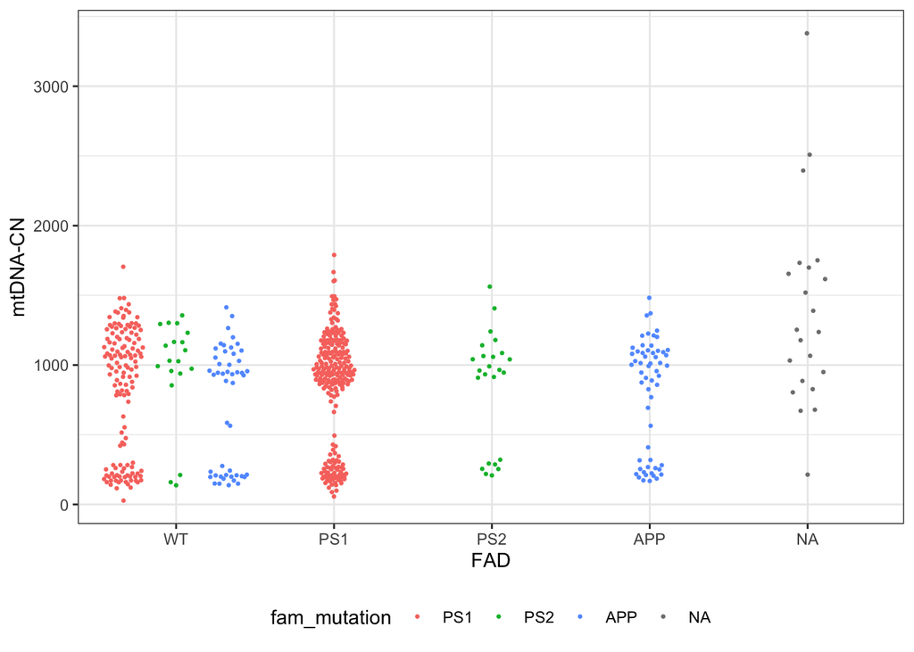